# Supervised Learning - Foundations Project: ReCell

## Problem Statement

### Business Context

Buying and selling used phones and tablets used to be something that happened on a handful of online marketplace sites. But the used and refurbished device market has grown considerably over the past decade, and a new IDC (International Data Corporation) forecast predicts that the used phone market would be worth \$52.7bn by 2023 with a compound annual growth rate (CAGR) of 13.6% from 2018 to 2023. This growth can be attributed to an uptick in demand for used phones and tablets that offer considerable savings compared with new models.

Refurbished and used devices continue to provide cost-effective alternatives to both consumers and businesses that are looking to save money when purchasing one. There are plenty of other benefits associated with the used device market. Used and refurbished devices can be sold with warranties and can also be insured with proof of purchase. Third-party vendors/platforms, such as Verizon, Amazon, etc., provide attractive offers to customers for refurbished devices. Maximizing the longevity of devices through second-hand trade also reduces their environmental impact and helps in recycling and reducing waste. The impact of the COVID-19 outbreak may further boost this segment as consumers cut back on discretionary spending and buy phones and tablets only for immediate needs.

### Objective

The rising potential of this comparatively under-the-radar market fuels the need for an ML-based solution to develop a dynamic pricing strategy for used and refurbished devices. ReCell, a startup aiming to tap the potential in this market, has hired you as a data scientist. They want you to analyze the data provided and build a linear regression model to predict the price of a used phone/tablet and identify factors that significantly influence it.

### Data Description

The data contains the different attributes of used/refurbished phones and tablets. The data was collected in the year 2021. The detailed data dictionary is given below.

- brand_name: Name of manufacturing brand
- os: OS on which the device runs
- screen_size: Size of the screen in cm
- 4g: Whether 4G is available or not
- 5g: Whether 5G is available or not
- main_camera_mp: Resolution of the rear camera in megapixels
- selfie_camera_mp: Resolution of the front camera in megapixels
- int_memory: Amount of internal memory (ROM) in GB
- ram: Amount of RAM in GB
- battery: Energy capacity of the device battery in mAh
- weight: Weight of the device in grams
- release_year: Year when the device model was released
- days_used: Number of days the used/refurbished device has been used
- normalized_new_price: Normalized price of a new device of the same model in euros
- normalized_used_price: Normalized price of the used/refurbished device in euros

## Importing necessary libraries

```python
# Installing the libraries with the specified version.
# uncomment and run the following line if Google Colab is being used
# !pip install scikit-learn==1.6.1 seaborn==0.13.2 matplotlib==3.10.0 numpy==2.0.2 pandas==2.2.2 -q --user
```

```python
# Installing the libraries with the specified version.
# uncomment and run the following lines if Jupyter Notebook is being used
# !pip install scikit-learn==1.6.1 seaborn==0.13.2 matplotlib==3.10.0 numpy==2.0.2 pandas==2.2.2 -q --user
```

**Note**: *After running the above cell, kindly restart the notebook kernel and run all cells sequentially from the start again.*

```python
# Libraries to help with reading and manipulating data
import numpy as np
import pandas as pd

# Libraries to help with data visualization
import matplotlib.pyplot as plt
import seaborn as sns

sns.set()

# split the data into train and test
from sklearn.model_selection import train_test_split

# to build linear regression_model
from sklearn.linear_model import LinearRegression

# to check model performance
from sklearn.metrics import mean_absolute_error, mean_squared_error, r2_score

# to build linear regression_model using statsmodels
import statsmodels.api as sm

# to compute VIF
from statsmodels.stats.outliers_influence import variance_inflation_factor
```

## Loading the dataset

```python
from google.colab import drive
drive.mount('/content/drive')
```

```python
df=pd.read_csv('/content/drive/MyDrive/Python Course/used_device_data.csv')
```

## Data Overview

The overview and steps of any dataset are to:

- Observing the first few rows of the dataset to check whether it has been loaded correctly or not.
- Getting information about the number of rows and columns in the dataset.
- Identifying the data types of the columns to ensure data is stored in the preferred format and the value of each property is as expected.
- Checking the statistical summary of the dataset to get an overview of the numerical columns of the data

## Displaying the first and last few rows of the dataset

```python
# Checking the first 5 rows of the data
df.head()
```

|  | brand_name | os | screen_size | 4g | 5g | main_camera_mp | selfie_camera_mp | int_memory | ram | battery | weight | release_year | days_used | normalized_used_price | normalized_new_price |
| --- | --- | --- | --- | --- | --- | --- | --- | --- | --- | --- | --- | --- | --- | --- | --- |
| 0 | Honor | Android | 14.50 | yes | no | 13.0 | 5.0 | 64.0 | 3.0 | 3020.0 | 146.0 | 2020 | 127 | 4.307572 | 4.715100 |
| 1 | Honor | Android | 17.30 | yes | yes | 13.0 | 16.0 | 128.0 | 8.0 | 4300.0 | 213.0 | 2020 | 325 | 5.162097 | 5.519018 |
| 2 | Honor | Android | 16.69 | yes | yes | 13.0 | 8.0 | 128.0 | 8.0 | 4200.0 | 213.0 | 2020 | 162 | 5.111084 | 5.884631 |
| 3 | Honor | Android | 25.50 | yes | yes | 13.0 | 8.0 | 64.0 | 6.0 | 7250.0 | 480.0 | 2020 | 345 | 5.135387 | 5.630961 |
| 4 | Honor | Android | 15.32 | yes | no | 13.0 | 8.0 | 64.0 | 3.0 | 5000.0 | 185.0 | 2020 | 293 | 4.389995 | 4.947837 |

```python
# Checking the last 5 rows of the data
df.tail()
```

|  | brand_name | os | screen_size | 4g | 5g | main_camera_mp | selfie_camera_mp | int_memory | ram | battery | weight | release_year | days_used | normalized_used_price | normalized_new_price |
| --- | --- | --- | --- | --- | --- | --- | --- | --- | --- | --- | --- | --- | --- | --- | --- |
| 3449 | Asus | Android | 15.34 | yes | no | NaN | 8.0 | 64.0 | 6.0 | 5000.0 | 190.0 | 2019 | 232 | 4.492337 | 6.483872 |
| 3450 | Asus | Android | 15.24 | yes | no | 13.0 | 8.0 | 128.0 | 8.0 | 4000.0 | 200.0 | 2018 | 541 | 5.037732 | 6.251538 |
| 3451 | Alcatel | Android | 15.80 | yes | no | 13.0 | 5.0 | 32.0 | 3.0 | 4000.0 | 165.0 | 2020 | 201 | 4.357350 | 4.528829 |
| 3452 | Alcatel | Android | 15.80 | yes | no | 13.0 | 5.0 | 32.0 | 2.0 | 4000.0 | 160.0 | 2020 | 149 | 4.349762 | 4.624188 |
| 3453 | Alcatel | Android | 12.83 | yes | no | 13.0 | 5.0 | 16.0 | 2.0 | 4000.0 | 168.0 | 2020 | 176 | 4.132122 | 4.279994 |

- Checking the last 5 rows of the dataset, I observe that there is a missing value in the main_camera_mp column for one of the entries.
- The device specifications and price information, however, are consistent with the dataset's description that appears in the columns.

## The shape of the dataset

```python
# Checking the shape of the data
df.shape
```

```
(3454, 15)
```

## The data types of the columns for the dataset

```python
# Checking column types and number of values
df.info()
```

```
<class 'pandas.core.frame.DataFrame'>
RangeIndex: 3454 entries, 0 to 3453
Data columns (total 15 columns):
 #   Column                 Non-Null Count  Dtype
---  ------                 --------------  -----
 0   brand_name             3454 non-null   object
 1   os                     3454 non-null   object
 2   screen_size            3454 non-null   float64
 3   4g                     3454 non-null   object
 4   5g                     3454 non-null   object
 5   main_camera_mp         3275 non-null   float64
 6   selfie_camera_mp       3452 non-null   float64
 7   int_memory             3450 non-null   float64
 8   ram                    3450 non-null   float64
 9   battery                3448 non-null   float64
 10  weight                 3447 non-null   float64
 11  release_year           3454 non-null   int64
 12  days_used              3454 non-null   int64
 13  normalized_used_price  3454 non-null   float64
 14  normalized_new_price   3454 non-null   float64
dtypes: float64(9), int64(2), object(4)
memory usage: 404.9+ KB
```

- Most columns in the data are numeric in nature ('int64' or 'float64' type).
- The brand_name, os, 4g, and 5g columns are string columns ('object' type).

## Statistical summary of the dataset

```python
# Checking Statistical summary of the dataset
df.describe().T
```

|  | count | mean | std | min | 25% | 50% | 75% | max |
| --- | --- | --- | --- | --- | --- | --- | --- | --- |
| screen_size | 3454.0 | 13.713115 | 3.805280 | 5.080000 | 12.700000 | 12.830000 | 15.340000 | 30.710000 |
| main_camera_mp | 3275.0 | 9.460208 | 4.815461 | 0.080000 | 5.000000 | 8.000000 | 13.000000 | 48.000000 |
| selfie_camera_mp | 3452.0 | 6.554229 | 6.970372 | 0.000000 | 2.000000 | 5.000000 | 8.000000 | 32.000000 |
| int_memory | 3450.0 | 54.573099 | 84.972371 | 0.010000 | 16.000000 | 32.000000 | 64.000000 | 1024.000000 |
| ram | 3450.0 | 4.036122 | 1.365105 | 0.020000 | 4.000000 | 4.000000 | 4.000000 | 12.000000 |
| battery | 3448.0 | 3133.402697 | 1299.682844 | 500.000000 | 2100.000000 | 3000.000000 | 4000.000000 | 9720.000000 |
| weight | 3447.0 | 182.751871 | 88.413228 | 69.000000 | 142.000000 | 160.000000 | 185.000000 | 855.000000 |
| release_year | 3454.0 | 2015.965258 | 2.298455 | 2013.000000 | 2014.000000 | 2015.500000 | 2018.000000 | 2020.000000 |
| days_used | 3454.0 | 674.869716 | 248.580166 | 91.000000 | 533.500000 | 690.500000 | 868.750000 | 1094.000000 |
| normalized_used_price | 3454.0 | 4.364712 | 0.588914 | 1.536867 | 4.033931 | 4.405133 | 4.755700 | 6.619433 |
| normalized_new_price | 3454.0 | 5.233107 | 0.683637 | 2.901422 | 4.790342 | 5.245892 | 5.673718 | 7.847841 |

## Checking duplicate values

```python
# Checking for duplicate values
f"Number of duplicate rows: {df.duplicated().sum()}"
```

```
'Number of duplicate rows: 0'
```

## Checking for missing values

```python
# Checking for missing values
df.isnull().sum()
```

|  | 0 |
| --- | --- |
| brand_name | 0 |
| os | 0 |
| screen_size | 0 |
| 4g | 0 |
| 5g | 0 |
| main_camera_mp | 179 |
| selfie_camera_mp | 2 |
| int_memory | 4 |
| ram | 4 |
| battery | 6 |
| weight | 7 |
| release_year | 0 |
| days_used | 0 |
| normalized_used_price | 0 |
| normalized_new_price | 0 |

**dtype:** int64

```python
# creating a copy of the data so that the original data remains unchanged
df = df.copy()
```

## Exploratory Data Analysis (EDA)

- EDA is an important part of any project involving data.
- It is important to investigate and understand the data better before building a model with it.
- A few questions have been mentioned below which will help you approach the analysis in the right manner and generate insights from the data.
- A thorough analysis of the data, in addition to the questions mentioned below, should be done.

**Questions**:

1. What does the distribution of normalized used device prices look like?
2. What percentage of the used device market is dominated by Android devices?
3. The amount of RAM is important for the smooth functioning of a device. How does the amount of RAM vary with the brand?
4. A large battery often increases a device's weight, making it feel uncomfortable in the hands. How does the weight vary for phones and tablets offering large batteries (more than 4500 mAh)?
5. Bigger screens are desirable for entertainment purposes as they offer a better viewing experience. How many phones and tablets are available across different brands with a screen size larger than 6 inches?
6. A lot of devices nowadays offer great selfie cameras, allowing us to capture our favorite moments with loved ones. What is the distribution of devices offering greater than 8MP selfie cameras across brands?
7. Which attributes are highly correlated with the normalized price of a used device?

**Questions 1 and 2 indeed pertain to univariate analysis:**

1.What does the distribution of normalized used device prices look like?

2.What percentage of the used device market is dominated by Android devices?

## Univariate Analysis

```python
# function to plot a boxplot and a histogram along the same scale.


def histogram_boxplot(data, feature, figsize=(15, 10), kde=False, bins=None):
    """
    Boxplot and histogram combined

    data: dataframe
    feature: dataframe column
    figsize: size of figure (default (15,10))
    kde: whether to show the density curve (default False)
    bins: number of bins for histogram (default None)
    """
    f2, (ax_box2, ax_hist2) = plt.subplots(
        nrows=2,  # Number of rows of the subplot grid= 2
        sharex=True,  # x-axis will be shared among all subplots
        gridspec_kw={"height_ratios": (0.25, 0.75)},
        figsize=figsize,
    )  # creating the 2 subplots
    sns.boxplot(
        data=data, x=feature, ax=ax_box2, showmeans=True, color="violet"
    )  # boxplot will be created and a triangle will indicate the mean value of the column
    sns.histplot(
        data=data, x=feature, kde=kde, ax=ax_hist2, bins=bins
    ) if bins else sns.histplot(
        data=data, x=feature, kde=kde, ax=ax_hist2
    )  # For histogram
    ax_hist2.axvline(
        data[feature].mean(), color="green", linestyle="--"
    )  # Add mean to the histogram
    ax_hist2.axvline(
        data[feature].median(), color="black", linestyle="-"
    )  # Add median to the histogram
```

```python
# function to create labeled barplots


def labeled_barplot(data, feature, perc=False, n=None):
    """
    Barplot with percentage at the top

    data: dataframe
    feature: dataframe column
    perc: whether to display percentages instead of count (default is False)
    n: displays the top n category levels (default is None, i.e., display all levels)
    """

    total = len(data[feature])  # length of the column
    count = data[feature].nunique()
    if n is None:
        plt.figure(figsize=(count + 2, 6))
    else:
        plt.figure(figsize=(n + 2, 6))

    plt.xticks(rotation=90, fontsize=15)
    ax = sns.countplot(
        data=data,
        x=feature,
        order=data[feature].value_counts().index[:n],
    )

    for p in ax.patches:
        if perc == True:
            label = "{:.1f}%".format(
                100 * p.get_height() / total
            )  # percentage of each class of the category
        else:
            label = p.get_height()  # count of each level of the category

        x = p.get_x() + p.get_width() / 2  # width of the plot
        y = p.get_height()  # height of the plot

        ax.annotate(
            label,
            (x, y),
            ha="center",
            va="center",
            size=12,
            xytext=(0, 5),
            textcoords="offset points",
        )  # annotate the percentage

    plt.show()  # show the plot
```

## Univariate Analysis of Numerical Columns

```python
histogram_boxplot(df, 'normalized_used_price', kde=True)
```

[output not shown]

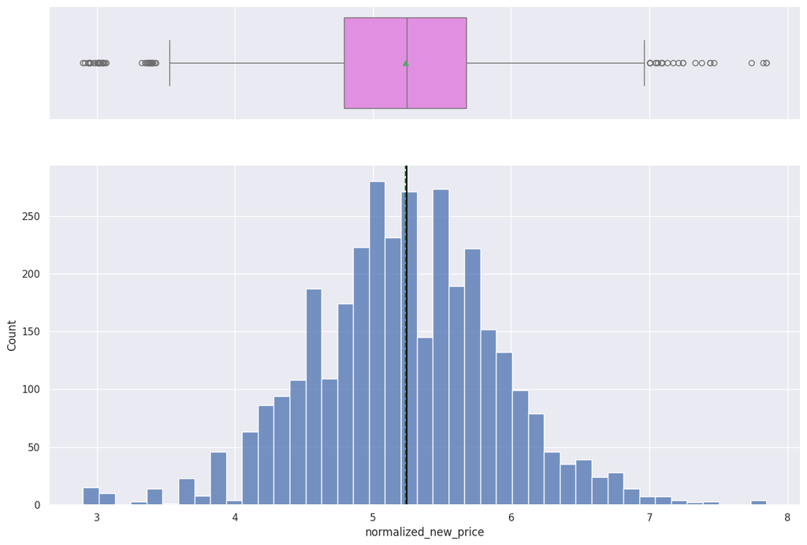

```python
histogram_boxplot(df, 'normalized_new_price')
```

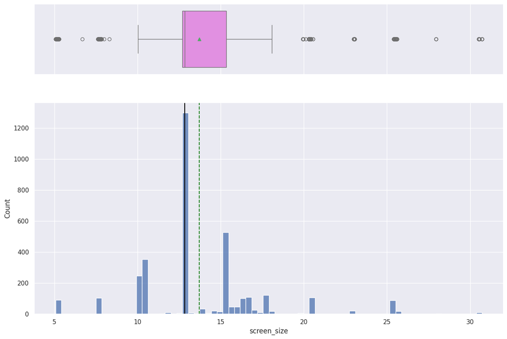

```python
histogram_boxplot(df, 'screen_size')
```

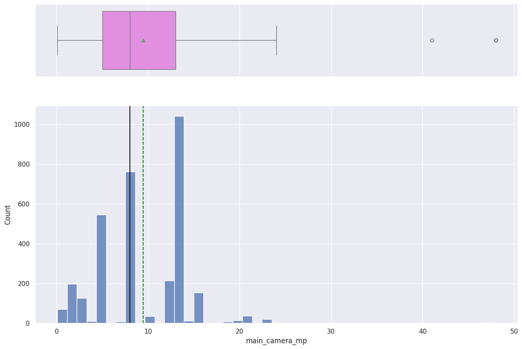

```python
histogram_boxplot(df, 'main_camera_mp')
```

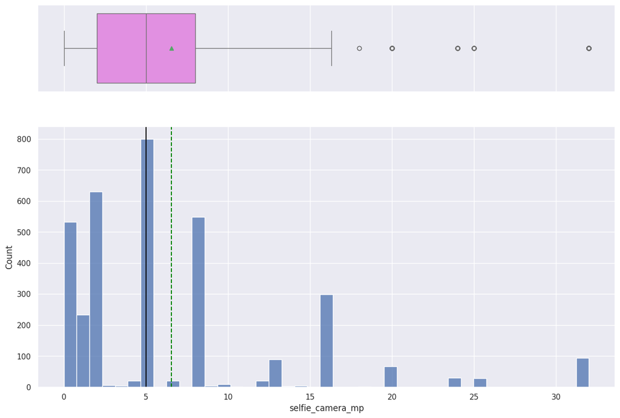

```python
histogram_boxplot(df, 'selfie_camera_mp')
```

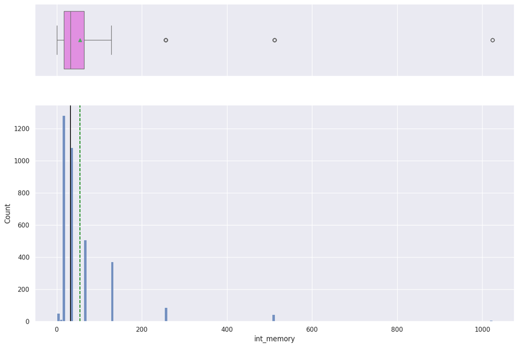

```python
histogram_boxplot(df, 'int_memory')
```

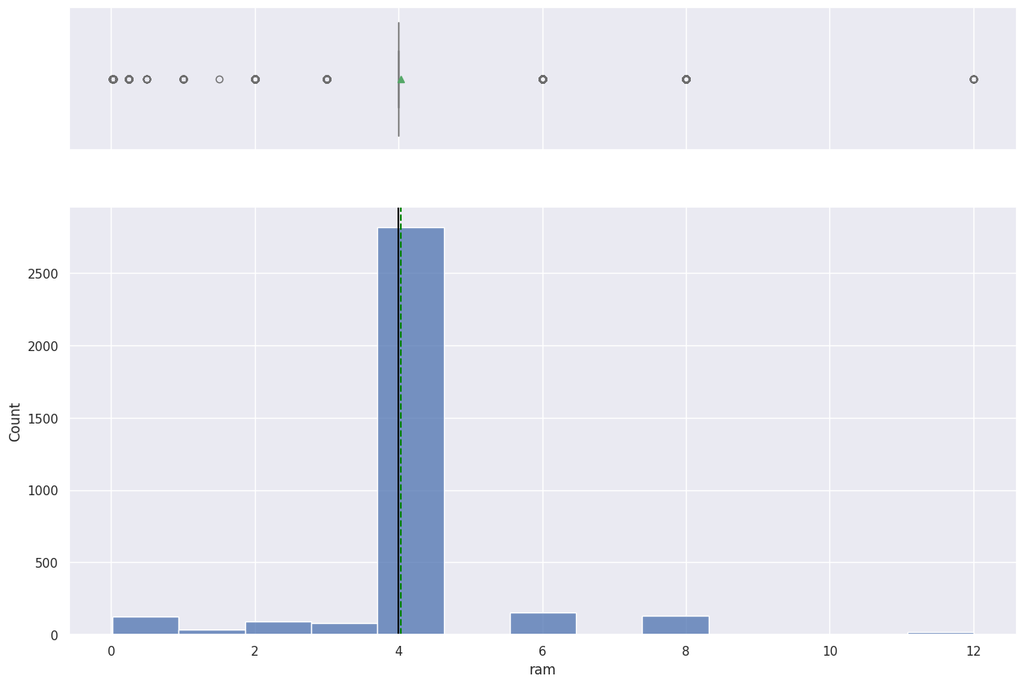

```python
histogram_boxplot(df, 'ram')
```

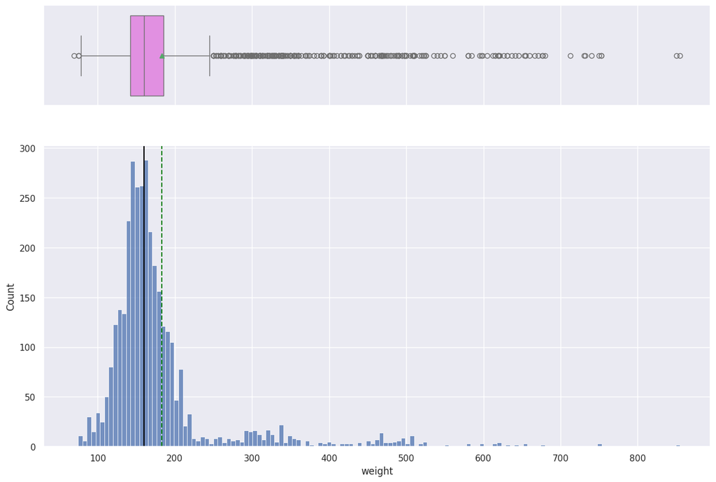

```python
histogram_boxplot(df, 'weight')
```

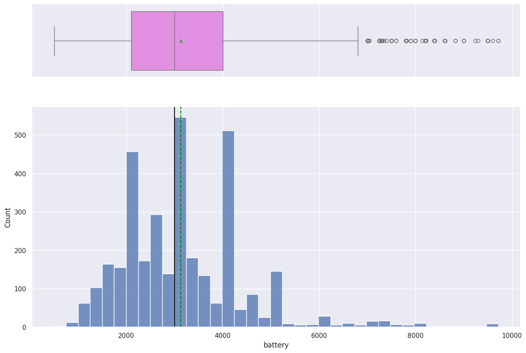

```python
histogram_boxplot(df, 'battery')
```

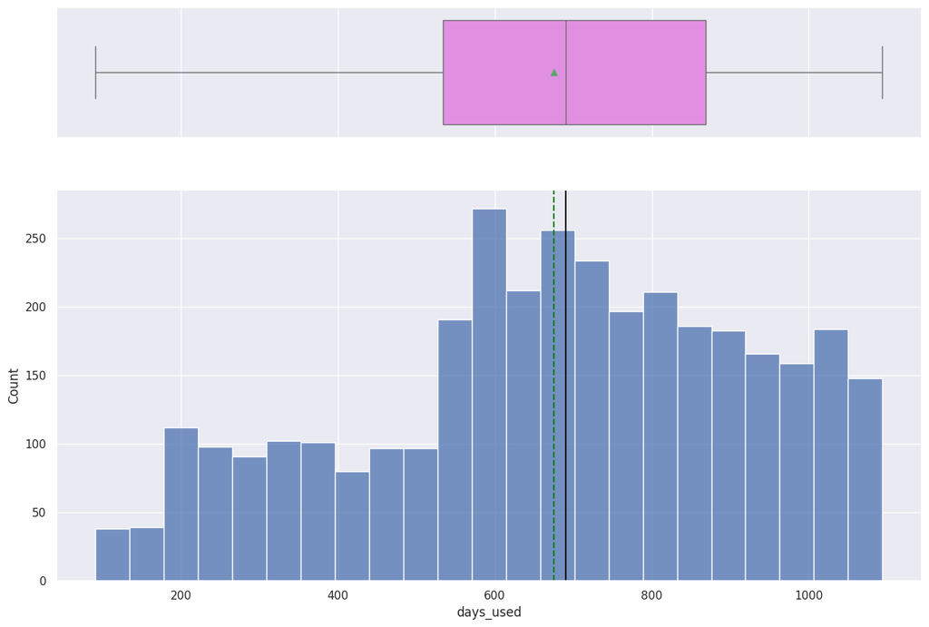

```python
histogram_boxplot(df, 'days_used')
```

## Univariate Analysis of Categorical Columns

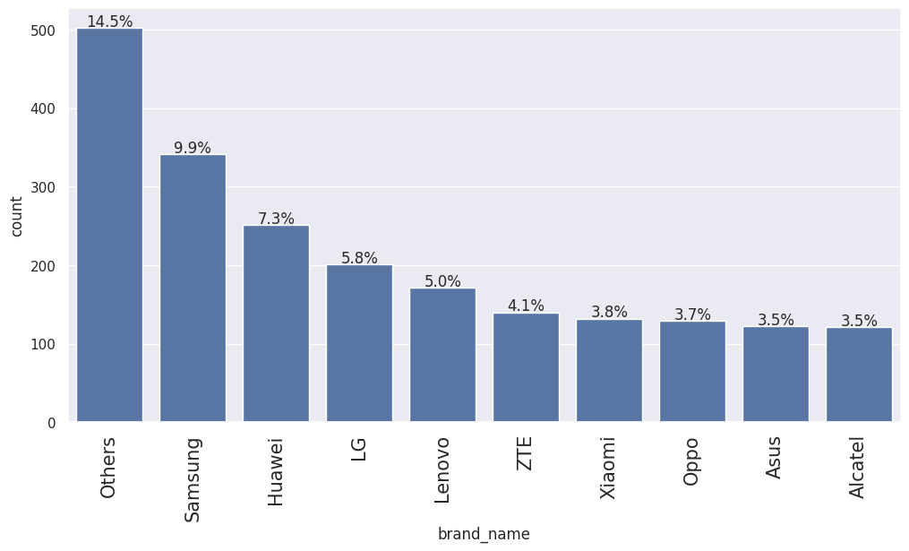

```python
labeled_barplot(df, 'brand_name', perc=True, n=10)
```

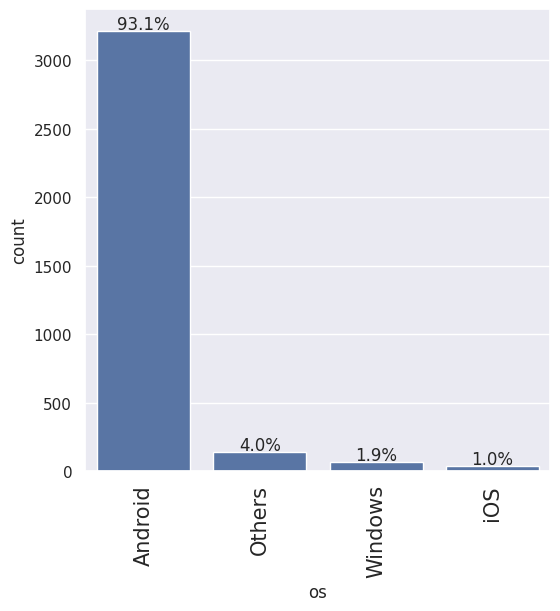

```python
labeled_barplot(df, "os", perc=True)
```

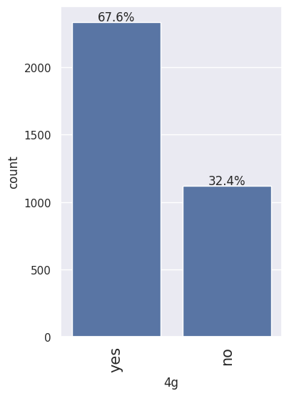

```python
labeled_barplot(df, "4g", perc=True)
```

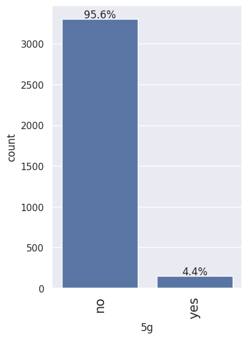

```python
labeled_barplot(df, "5g", perc=True)
```

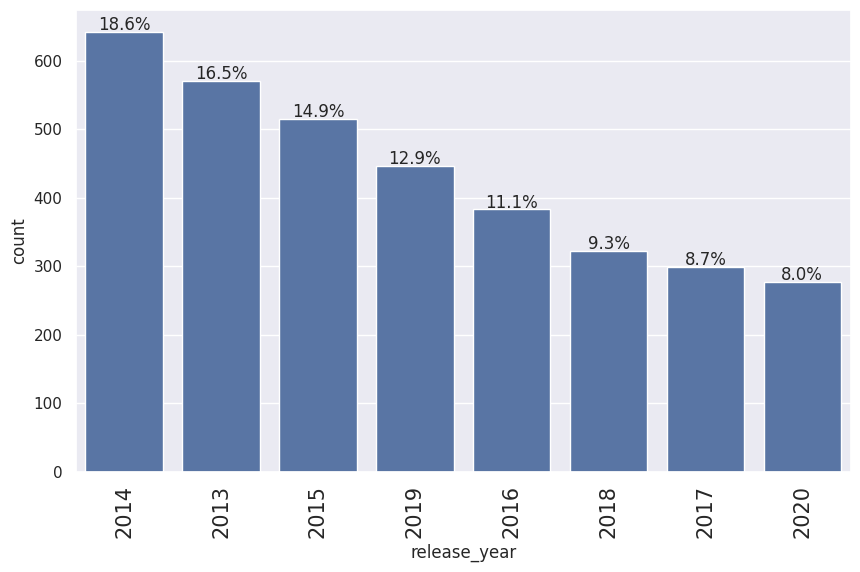

```python
labeled_barplot(df, "release_year", perc=True)
```

## Observations from Univariate Analysis

**Numerical Features (Distributions from Histogram and Boxplot):**

**normalized_used_price**: It appears to be roughly symmetric with a slight left skew on the distribution. Mostly, used device prices fall between 4 and 5 (from normalized units), at a peak around the median of 4.4 and a mean of 4.36.

**normalized_new_price**: Just like used prices, new device prices are also, to some degree, symmetric but with a slight left skew. Most of the new device prices are between 4.8 and 5.8 (from normalized units), with a median around 5.25 and a mean of 5.23.

**screen_size**: It appears the screen sizes shows a concentration between 12 cm and 16 cm from the distribution, with a median of 12.83 cm. There are some outliers with much larger screen sizes, coming from the tablets.

**main_camera_mp**: It appears the main camera megapixel count is highly skewed to the right, with a large number of devices having 5 MP, 8 MP, or 13 MP cameras. The median is 8 MP and the mean is 9.46 MP. There are a few devices with very high MP counts, which are creating a long tail.

**selfie_camera_mp**: It ppears to also be right-skewed, with many devices having 2 MP, 5 MP, or 8 MP front cameras. The median is 5 MP and the mean is 6.55 MP, with outliers up to 32 MP.

**int_memory**: Internal memory is heavily skewed to the right, with 16 GB, 32 GB, and 64 GB being common. The median is 32 GB, but the mean is 54.57 GB due to devices with much larger memory (up to 1024 GB).

**ram**: The RAM distribution appears to concentrate around 4 GB, which is also the median and mode. There are equally some devices with lower RAM and a few with higher RAM (up to 12 GB), but 4 GB is mostly common.

**weight**: Generally, weight distribution is concentrated between 140g and 200g, with a median of 160g. Indeed, it appears to be right skew, indicating some heavier devices, mainly tablets.

**battery**: The Battery capacity is right-skewed, with a significant number of devices around 3000 mAh and 4000 mAh. The median is 3000 mAh and the mean is 3133.4 mAh, with a range up to 9720 mAh.

**days_used**: The number of days a device has been used shows a degree of normal distribution but with a left skew. Most of the devices have been used for 500-900 days, with the median around 690 days and mean of 674 days.

**Categorical Features (Distributions from Bar Plots):**

**os**: Overwhelmingly, Android devices dominate the market and representing over 90% of the devices in the dataset. iOS devices make up a small percentage.

## Bivariate Analysis

Questions 3 through 7 indeed pertain to bivariate analysis

**Perform a bivariate analysis on the `df` DataFrame to**:

1. Visualize the distribution of RAM across different device brands using a box or violin plot.
2. Filter for devices with a battery larger than 4500 mAh and visualize the distribution of their weight using a histogram and boxplot.
3. Count and visualize with a bar plot the number of devices with a screen size larger than 15.24 cm (6 inches) per brand.
4. Filter for devices with a selfie camera greater than 8MP and visualize their distribution across brands using a bar plot.
5. Calculate and visualize with a heatmap the correlation matrix of numerical features with 'normalized_used_price'. Finally, summarize the key insights derived from these analyses to answer the posed questions about the data.

**To visualize the distribution of RAM across different device brands, using a box.**

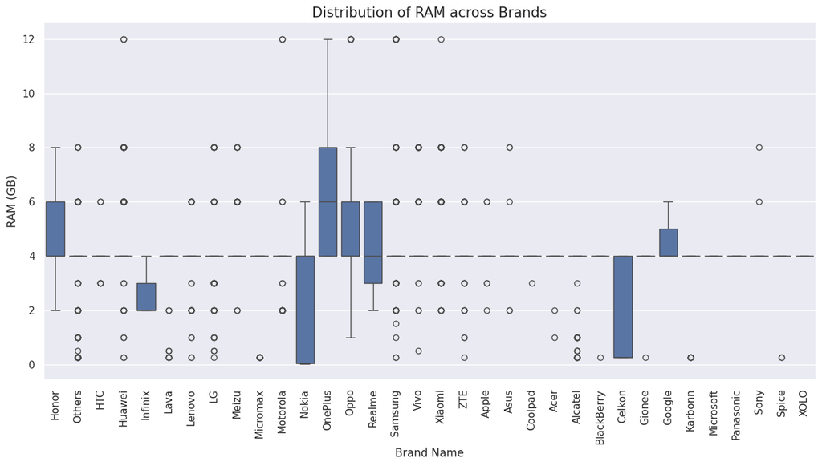

```python
plt.figure(figsize=(15, 7))
sns.boxplot(x='brand_name', y='ram', data=df);
plt.title('Distribution of RAM across Brands', fontsize=15)
plt.xlabel('Brand Name', fontsize=12)
plt.ylabel('RAM (GB)', fontsize=12)
plt.xticks(rotation=90)
plt.show()
```

**To visualize the distribution of weight for devices with a battery larger than 4500 mAh, first, I will filter the DataFrame, and then use the histogram_boxplot function to display both a histogram and a boxplot of the 'weight' column.**

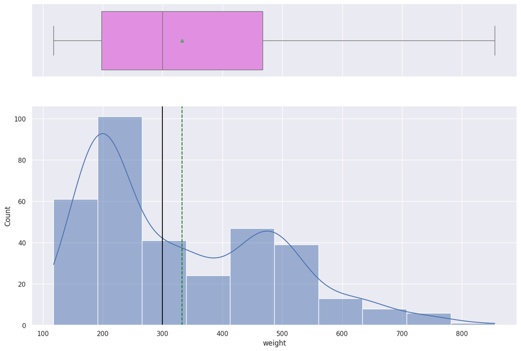

```python
df_large_battery = df[df['battery'] > 4500]
histogram_boxplot(df_large_battery, 'weight', kde=True)
```

**To count and visualize the number of devices with a screen size larger than 15.24 cm (6 inches) per brand, first, I will filter the DataFrame based on screen size, then count the occurrences of each brand, and finally use the labeled_barplot function to visualize this data.**

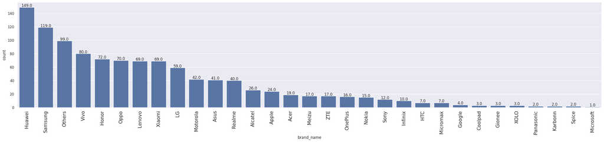

[figure not shown]

```python
df_large_screen = df[df['screen_size'] > 15.24]
plt.figure(figsize=(15, 7))
labeled_barplot(df_large_screen, 'brand_name', perc=False, n=None)
plt.title('Number of Devices with Screen Size > 15.24 cm per Brand', fontsize=15)
plt.xlabel('Brand Name', fontsize=12)
plt.ylabel('Number of Devices', fontsize=12)
plt.xticks(rotation=90)
plt.show()
```

**To filter for devices with a selfie camera greater than 8MP and visualize their distribution across brands, first, I will filter the DataFrame based on the selfie camera resolution and then use the labeled_barplot function to display the count of these devices for each brand.**

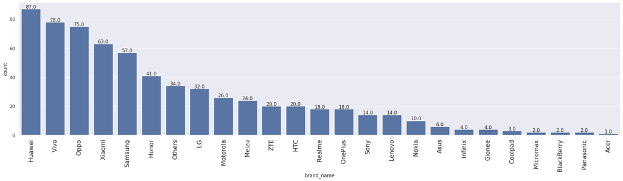

[figure not shown]

```python
df_high_selfie_camera = df[df['selfie_camera_mp'] > 8]
plt.figure(figsize=(15, 7))
labeled_barplot(df_high_selfie_camera, 'brand_name', perc=False, n=None)
plt.title('Number of Devices with Selfie Camera > 8MP per Brand', fontsize=15)
plt.xlabel('Brand Name', fontsize=12)
plt.ylabel('Number of Devices', fontsize=12)
plt.xticks(rotation=90)
plt.show()
```

**To visualize the correlation matrix of numerical features with 'normalized_used_price', first, I will select all numerical columns from the DataFrame, calculate their correlation, and then use seaborn's heatmap to display the correlations, focusing on the target variable 'normalized_used_price'.**

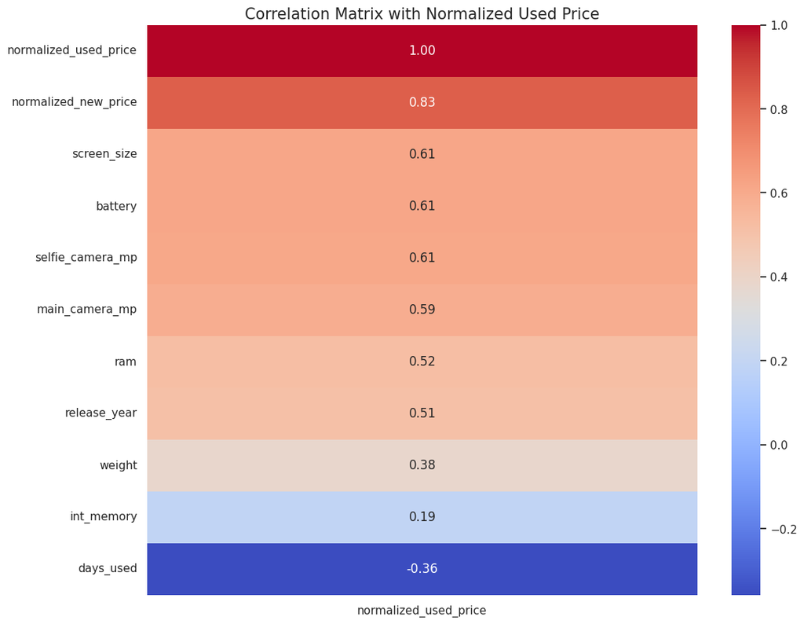

```python
plt.figure(figsize=(12, 10))
sns.heatmap(df.select_dtypes(include=np.number).corr()[['normalized_used_price']].sort_values(by='normalized_used_price', ascending=False), annot=True, cmap='coolwarm', fmt=".2f");
plt.title('Correlation Matrix with Normalized Used Price', fontsize=15)
plt.show()
```

## Observation from Bivariate Analysis:

1. **RAM Distribution across Brands**: The box plot shows significant variation for RAM distribution across the brands. Some brands like Samsung, Apple, and OnePlus tend to have more consistent distributions with higher RAM capacities while others like Oppo and Xiaomi show a wider range, including devices with lower RAM.
2. **Weight Distribution for Devices with Large Batteries**: Apparently, For devices with batteries larger than 4500 mAh, the histogram and boxplot of weight shows that most of these devices fall within a certain weight range (e.g., 180-250 grams), but there are also higher outliers. This indicates that larger batteries contribute to increased device weight, moreover, other components and design also play a major role.
3. **Devices with Large Screens (> 15.24 cm) per Brand**: The bar plot shows that brands like Huawei, Samsung, and Apple have a substantial number of devices with screen sizes greater than 15.24 cm (6 inches). This reveals that these brands cater more to the demand for larger screen devices for productivity and entertainment.
4. **Devices with High Selfie Cameras (> 8MP) per Brand**: The distribution of devices with selfie cameras greater than 8MP indicates that many brands, including Huawei,Samsung, and Xiaomi offer a good number of devices with high-resolution front cameras. This reflects the essence of selfie cameras in consumer preferences.
5. **Correlation with Normalized Used Price**: The heatmap of correlations with 'normalized_used_price' highlights which numerical features have the strongest relationship with the used price. Features such as normalized_new_price, int_memory, and ram, show a strong positive correlation, while days_used might have a negative correlation. Other features such as selfie_camera_mp, main_camera_mp, and screen_size will also show their respective strengths of correlation, revealing their influence on the used device's price.

## Data Preprocessing

- Missing value treatment
- Feature engineering (if needed)
- Outlier detection and treatment (if needed)
- Preparing data for modeling
- Any other preprocessing steps (if needed)

I will start by addressing the missing values in the dataset. First, I will impute the missing values for numerical features like main_camera_mp, selfie_camera_mp, int_memory, ram, battery, and weight using the median, because it is robust to outliers, and these columns were shown to have skewed distributions in the univariate analysis. This will prepare the data for subsequent preprocessing steps.

## Handle Missing Values

Impute missing values in specified numerical columns using their medians.

To impute missing values for 'main_camera_mp', 'selfie_camera_mp', 'int_memory', 'ram', 'battery', and 'weight' columns with their respective medians, I will calculate the median for each column and then use the fillna() method. After imputation, I will verify that all missing values have been addressed.

```python
for col in ['main_camera_mp', 'selfie_camera_mp', 'int_memory', 'ram', 'battery', 'weight']:
    median_val = df[col].median()
    df[col] = df[col].fillna(median_val)

# Verifying that there are no more missing values
print("Missing values after imputation:")
print(df.isnull().sum())
```

```
Missing values after imputation:
brand_name               0
os                       0
screen_size              0
4g                       0
5g                       0
main_camera_mp           0
selfie_camera_mp         0
int_memory               0
ram                      0
battery                  0
weight                   0
release_year             0
days_used                0
normalized_used_price    0
normalized_new_price     0
dtype: int64
```

## Feature Engineering (if needed)

First, I will create a new feature 'age_of_model' by subtracting 'release_year' from 2021, and then drop the original 'release_year' column as its information is now encapsulated in the new feature. This directly addresses the first and third instructions of the subtask.

```python
# Check if 'release_year' column exists before performing operations
if 'release_year' in df.columns:
    df['age_of_model'] = 2021 - df['release_year']
    df.drop('release_year', axis=1, inplace=True)
    print("New feature 'age_of_model' created and 'release_year' dropped.")
    print(df[['age_of_model']].head())
else:
    # If 'release_year' is already dropped, 'age_of_model' might already exist or this step is redundant.
    # We'll check for 'age_of_model' existence and print its head if present.
    if 'age_of_model' in df.columns:
        print("'release_year' column not found, but 'age_of_model' already exists. Skipping feature engineering step.")
        print(df[['age_of_model']].head())
    else:
        print("Error: 'release_year' column not found and 'age_of_model' was not created.")
```

```
New feature 'age_of_model' created and 'release_year' dropped.
   age_of_model
0             1
1             1
2             1
3             1
4             1
```

### Evaluation of Other Feature Engineering Opportunities

Beyond `age_of_model`, several other features could potentially be engineered to enrich the dataset and improve model performance. These include:

- **Camera Quality Score**: A combined score from `main_camera_mp` and `selfie_camera_mp` (e.g., sum or weighted average) could represent overall camera capability.
- **Screen Density (PPI)**: If screen resolution data were available, combining it with `screen_size` could yield pixels per inch, a key indicator of display quality.
- **Performance Index**: A combined feature from `ram` and `int_memory` could serve as a proxy for the device's overall performance capacity.
- **Battery Density**: Dividing `battery` by `weight` could indicate battery efficiency relative to device size, which might influence user perception and price.
- **Connectivity Feature**: Combining `4g` and `5g` into a single ordinal feature (e.g., 'no_4g/5g', '4g_only', '4g_and_5g') could simplify connectivity representation.

For this foundational project, the `age_of_model` feature is a clear and impactful addition. More complex feature engineering would typically be explored in subsequent iterative model refinement steps, after establishing a baseline with simpler features.

## Outlier Detection and Treatment (if needed)

First, I will re-examine the box plots for all numerical features to visually identify potential outliers. I will start with 'screen_size' using the histogram_boxplot function.

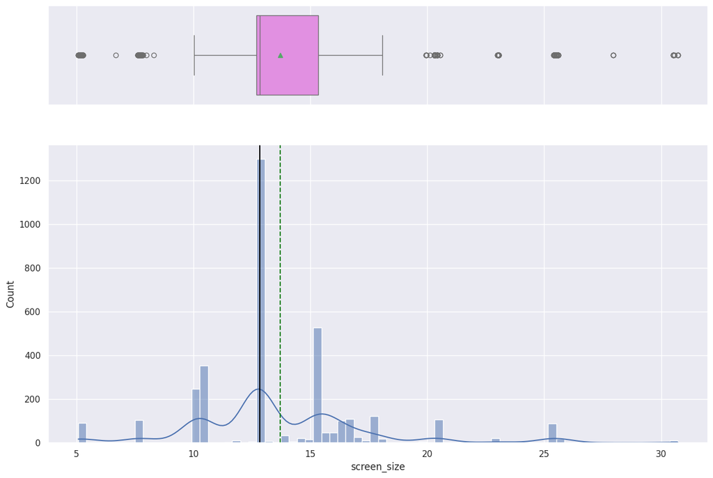

```python
histogram_boxplot(df, 'screen_size', kde=True)
```

I will continue to re-examine the box plots for all numerical features to visually identify potential outliers. Next is 'main_camera_mp' using the histogram_boxplot function.

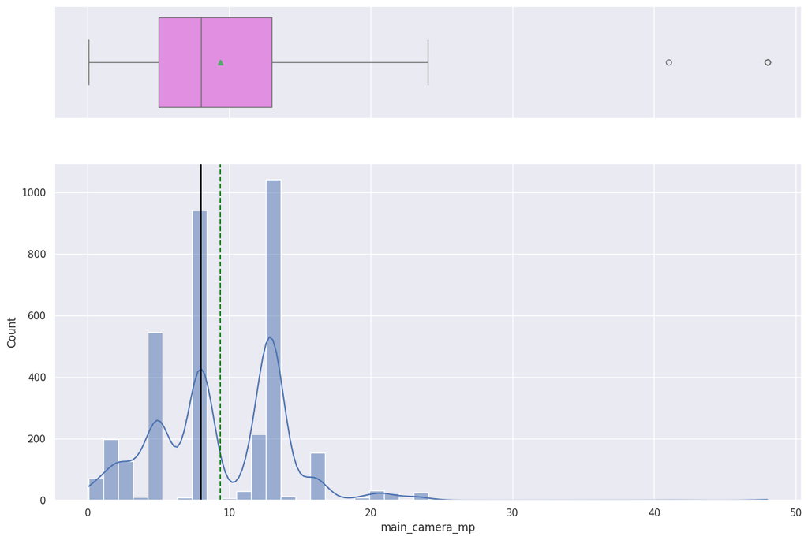

```python
histogram_boxplot(df, 'main_camera_mp', kde=True)
```

I will continue to re-examine the box plots for all numerical features to visually identify potential outliers. Next will be 'selfie_camera_mp' using the histogram_boxplot function.

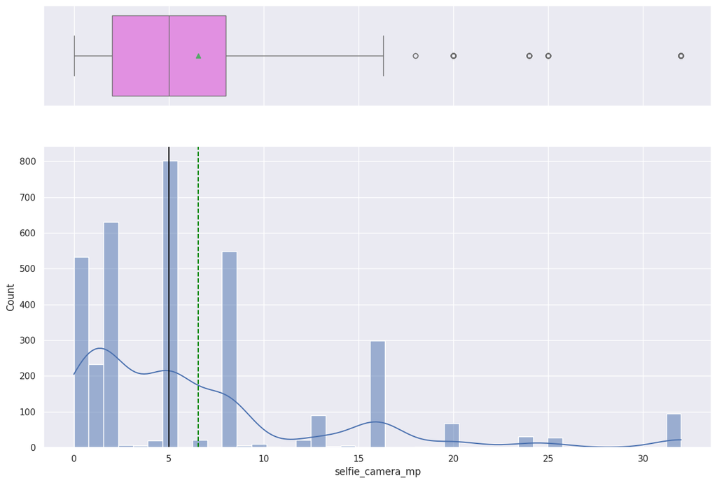

```python
histogram_boxplot(df, 'selfie_camera_mp', kde=True)
```

I will continue to re-examine the box plots for all numerical features to visually identify potential outliers. Next wil be 'int_memory' using the histogram_boxplot function.

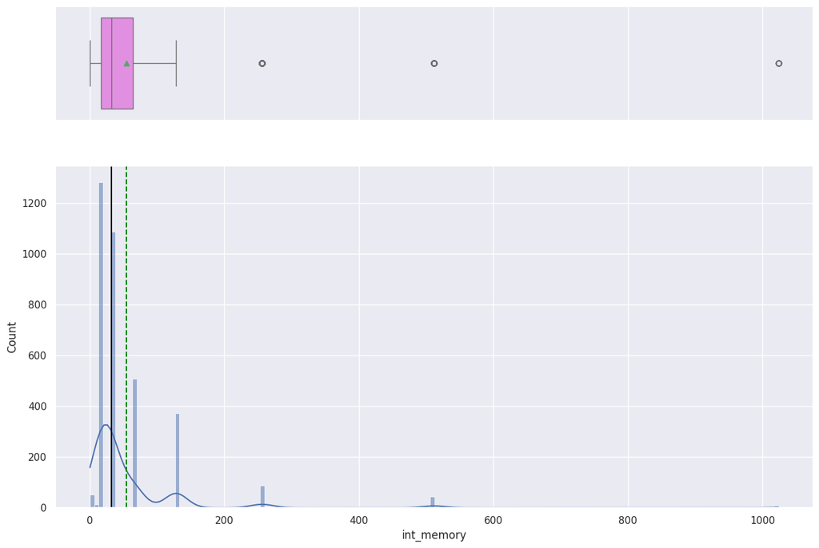

```python
histogram_boxplot(df, 'int_memory', kde=True)
```

I will continue to re-examine the box plots for all numerical features to visually identify potential outliers. Next is 'ram' using the histogram_boxplot function

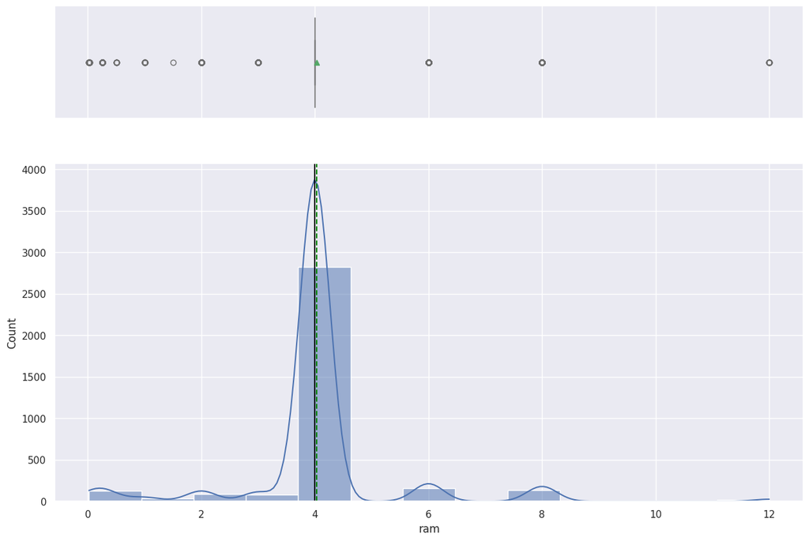

```python
histogram_boxplot(df, 'ram', kde=True)
```

I will continue to re-examine the box plots for all numerical features to visually identify potential outliers. Next will be 'battery' using the histogram_boxplot function.

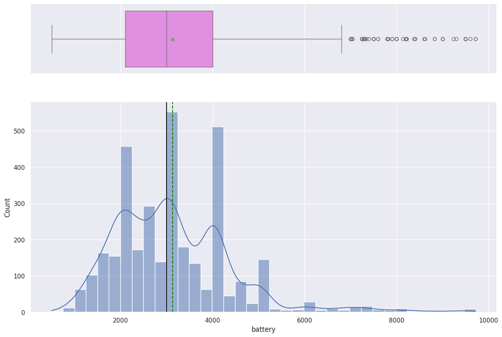

```python
histogram_boxplot(df, 'battery', kde=True)
```

I will continue to re-examine the box plots for all numerical features to visually identify potential outliers. Next will be 'weight' using the histogram_boxplot function.

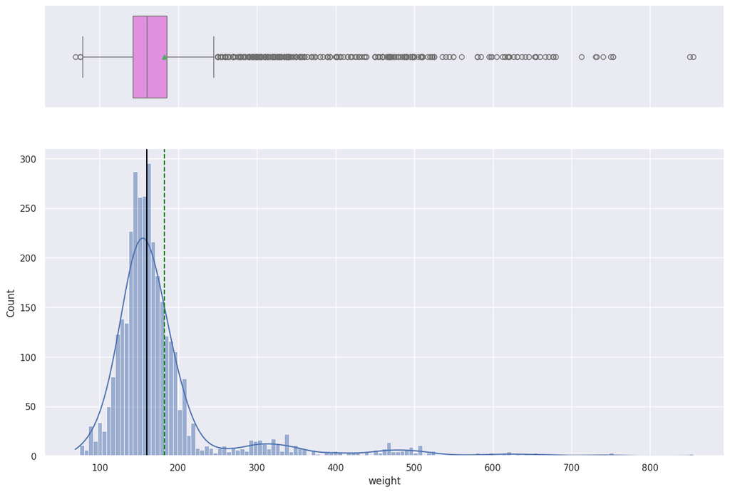

```python
histogram_boxplot(df, 'weight', kde=True)
```

I will continue to re-examine the box plots for all numerical features to visually identify potential outliers. Next is 'days_used' using the histogram_boxplot function.

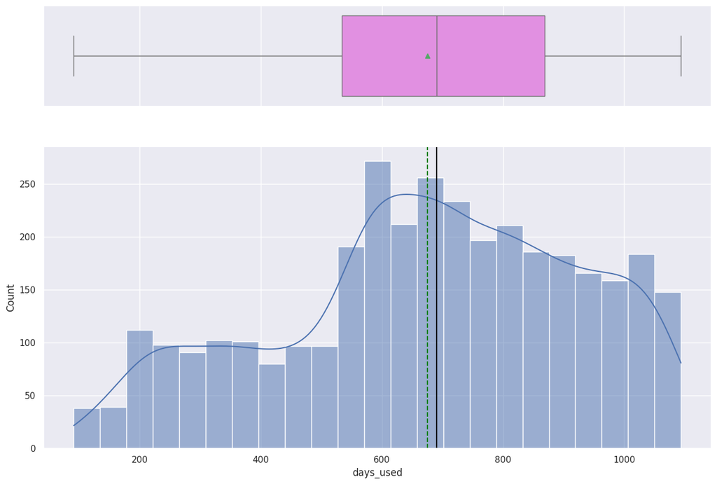

```python
histogram_boxplot(df, 'days_used', kde=True)
```

I will continue to re-examine the box plots for all numerical features to visually identify potential outliers. Next will be 'normalized_used_price' using the histogram_boxplot function.

```python
histogram_boxplot(df, 'normalized_used_price', kde=True)
```

[output not shown]

I will continue to re-examine the box plots for all numerical features to visually identify potential outliers. Next is 'normalized_new_price' using the histogram_boxplot function.

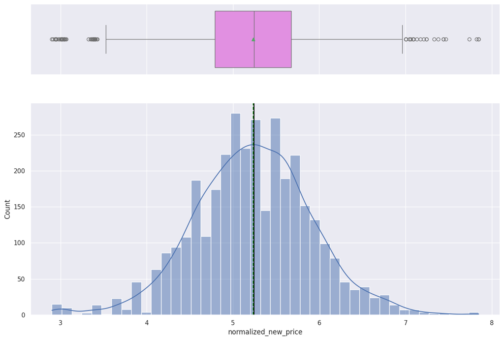

```python
histogram_boxplot(df, 'normalized_new_price', kde=True)
```

I will re-examine the box plot for the newly created numerical feature 'age_of_model' to visually identify potential outliers.

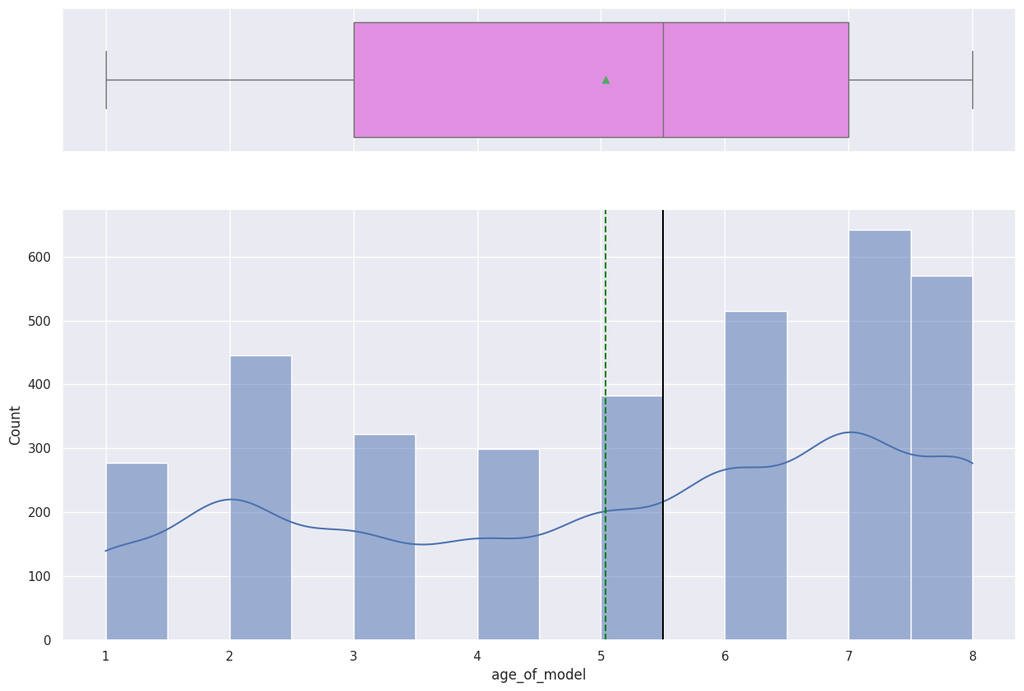

```python
histogram_boxplot(df, 'age_of_model', kde=True)
```

## Outlier Analysis Summary and Treatment Strategy

Based on the re-examination of box plots for all numerical features, the following observations and treatment strategies are proposed:

**1. `screen_size`**: No outlier treatment is necessary. It shows that the dataset includes both phones and tablets, these larger screen sizes (e.g., 25.5 cm, 30.71 cm) are representations of tablets. However, it is an indication of diverse device types in the dataset.

**3. `selfie_camera_mp`**: This feature shows outliers on the higher end (up to 32 MP). These values correspond to devices with a high-resolution front cameras. These can be legitimate variations in the device specifications and no outlier treatment is necessary.

**4. `int_memory`**: This feature shows numerous outliers on the higher side, with values exceeding significantly beyond the range (e.g., 1024 GB). While 1TB (1024GB) internal memory is available in modern premium devices, the extreme values are valid high-end specifications and no outlier treatment is necessary.

**5. `ram`**: The ram shows some outliers on both the lower and higher sides. While 4GB RAM is most common, some devices have 2GB, and others have 6GB, 8GB, or even 12GB. These variations are legitimate specifications found in the market and no outlier treatment is necessary.

**6. `battery`**: Battery capacity shows outliers on the higher side (up to 9720 mAh). Very large batteries Devices, especially tablets, exist. These high values are accurate representations of specific device models and no outlier treatment is necessary.

**7. `weight`**: Primarily, the weight shows outliers on the higher side (up to 855g).It is expected as heavier devices sometimes correspond to larger screen sizes (tablets) or devices with larger batteries. These are legitimate physical characteristics and no outlier treatment is necessary.

**9. `normalized_used_price`**: This normalized_used_price shows a few outliers on both the lower and higher ends. However, these represent cheap or expensive used devices. These are prices and could be legitimate, as we are trying to predict this variable, we should leave them, as they contribute to the full range of price prediction. Therefore, no outlier treatment is necessary.

**10. `normalized_new_price`**: This feature also shows some outliers on both ends and it is similia to used price. These is correspond to budget or premium devices. It's important to retain them to capture the full spectrum of new device pricing. Therefore, no outlier treatment is necessary.

## Prepare Data for Modeling

Perform necessary transformations, such as one-hot encoding for categorical variables and scaling numerical features, to prepare the data for linear regression modeling.

First, I will identify the categorical columns and apply one-hot encoding to them using pd.get_dummies(). This step converts categorical variables into a format suitable for linear regression models and addresses the first two instructions.

```python
categorical_cols = ['brand_name', 'os', '4g', '5g']
df_encoded = pd.get_dummies(df, columns=categorical_cols, drop_first=True)

print("DataFrame after one-hot encoding categorical variables:")
print(df_encoded.head())
print(f"New shape of DataFrame: {df_encoded.shape}")
```

```
DataFrame after one-hot encoding categorical variables:
   screen_size  main_camera_mp  selfie_camera_mp  int_memory  ram  battery  \
0        14.50            13.0               5.0        64.0  3.0   3020.0
1        17.30            13.0              16.0       128.0  8.0   4300.0
2        16.69            13.0               8.0       128.0  8.0   4200.0
3        25.50            13.0               8.0        64.0  6.0   7250.0
4        15.32            13.0               8.0        64.0  3.0   5000.0

   weight  days_used  normalized_used_price  normalized_new_price  ...  \
0   146.0        127               4.307572              4.715100  ...
1   213.0        325               5.162097              5.519018  ...
2   213.0        162               5.111084              5.884631  ...
3   480.0        345               5.135387              5.630961  ...
4   185.0        293               4.389995              4.947837  ...

   brand_name_Spice  brand_name_Vivo  brand_name_XOLO  brand_name_Xiaomi  \
0             False            False            False              False
1             False            False            False              False
2             False            False            False              False
3             False            False            False              False
4             False            False            False              False

   brand_name_ZTE  os_Others  os_Windows  os_iOS  4g_yes  5g_yes
0           False      False       False   False    True   False
1           False      False       False   False    True    True
2           False      False       False   False    True    True
3           False      False       False   False    True    True
4           False      False       False   False    True   False

[5 rows x 49 columns]
New shape of DataFrame: (3454, 49)
```

```python
from sklearn.preprocessing import StandardScaler

# Identify numerical columns to scale (excluding target)
numerical_cols = df_encoded.select_dtypes(include=np.number).columns.tolist()
numerical_cols.remove('normalized_used_price')

# Ensure 'age_of_model' is treated as numerical for scaling if it's already there
# The imputation was intended for 'df' but needs to be explicitly applied to 'df_encoded' before scaling.
# Columns identified to have missing values from df.info() were: main_camera_mp, selfie_camera_mp, int_memory, ram, battery, weight

# Re-apply median imputation to numerical columns that still have NaNs in df_encoded
for col in ['main_camera_mp', 'selfie_camera_mp', 'int_memory', 'ram', 'battery', 'weight']:
    if col in df_encoded.columns and df_encoded[col].isnull().any():
        median_val = df_encoded[col].median()
        df_encoded[col] = df_encoded[col].fillna(median_val)

# Initialize StandardScaler
scaler = StandardScaler()

# Apply scaling to numerical features
df_encoded[numerical_cols] = scaler.fit_transform(df_encoded[numerical_cols])

print("Numerical features scaled successfully.")
print(df_encoded[numerical_cols].head())
```

```
Numerical features scaled successfully.
   screen_size  main_camera_mp  selfie_camera_mp  int_memory       ram  \
0     0.206818        0.769335         -0.222941    0.111324 -0.759524
1     0.942744        0.769335          1.355830    0.865025  2.905851
2     0.782417        0.769335          0.207633    0.865025  2.905851
3     3.097957        0.769335          0.207633    0.111324  1.439701
4     0.422339        0.769335          0.207633    0.111324 -0.759524

    battery    weight  days_used  normalized_new_price  age_of_model
0 -0.087163 -0.415615  -2.204315             -0.757832     -1.755669
1  0.898683  0.343018  -1.407676              0.418281     -1.755669
2  0.821663  0.343018  -2.063495              0.953164     -1.755669
3  3.170750  3.366229  -1.327208              0.582051     -1.755669
4  1.437817  0.025977  -1.536426             -0.417343     -1.755669
```

All numerical features have been scaled and categorical features have been one-hot encoded and integrated into df_encoded. The target variable normalized_used_price is also present in df_encoded. I will now print the head of the final DataFrame to confirm its structure.

```python
print("Final DataFrame ready for modeling:")
print(df_encoded.head())
print(f"Final shape of DataFrame: {df_encoded.shape}")
```

```
Final DataFrame ready for modeling:
   screen_size  main_camera_mp  selfie_camera_mp  int_memory       ram  \
0     0.206818        0.769335         -0.222941    0.111324 -0.759524
1     0.942744        0.769335          1.355830    0.865025  2.905851
2     0.782417        0.769335          0.207633    0.865025  2.905851
3     3.097957        0.769335          0.207633    0.111324  1.439701
4     0.422339        0.769335          0.207633    0.111324 -0.759524

    battery    weight  days_used  normalized_used_price  normalized_new_price  \
0 -0.087163 -0.415615  -2.204315               4.307572             -0.757832
1  0.898683  0.343018  -1.407676               5.162097              0.418281
2  0.821663  0.343018  -2.063495               5.111084              0.953164
3  3.170750  3.366229  -1.327208               5.135387              0.582051
4  1.437817  0.025977  -1.536426               4.389995             -0.417343

   ...  brand_name_Spice  brand_name_Vivo  brand_name_XOLO  brand_name_Xiaomi  \
0  ...             False            False            False              False
1  ...             False            False            False              False
2  ...             False            False            False              False
3  ...             False            False            False              False
4  ...             False            False            False              False

   brand_name_ZTE  os_Others  os_Windows  os_iOS  4g_yes  5g_yes
0           False      False       False   False    True   False
1           False      False       False   False    True    True
2           False      False       False   False    True    True
3           False      False       False   False    True    True
4           False      False       False   False    True   False

[5 rows x 49 columns]
Final shape of DataFrame: (3454, 49)
```

### Insights

- The dataset is now thoroughly preprocessed, with missing values handled, a new relevant feature engineered, outliers assessed, and data transformed for machine learning, making it ready for the model building phase.

## EDA

- It is a good idea to explore the data once again after manipulating it.

Display the first few rows, data types, non-null counts, and statistical summary of the df_encoded DataFrame to confirm the effect of preprocessing (one-hot encoding and scaling).

## Re-examine Data Overview

Displaying the first few rows, information (data types, non-null counts), and statistical summary of the `df_encoded` DataFrame to confirm the effect of preprocessing (one-hot encoding and scaling).

To confirm the structure of the df_encoded DataFrame after one-hot encoding and scaling, I will display its first few rows.

```python
print(df_encoded.head())
```

```
   screen_size  main_camera_mp  selfie_camera_mp  int_memory       ram  \
0     0.206818        0.769335         -0.222941    0.111324 -0.759524
1     0.942744        0.769335          1.355830    0.865025  2.905851
2     0.782417        0.769335          0.207633    0.865025  2.905851
3     3.097957        0.769335          0.207633    0.111324  1.439701
4     0.422339        0.769335          0.207633    0.111324 -0.759524

    battery    weight  days_used  normalized_used_price  normalized_new_price  \
0 -0.087163 -0.415615  -2.204315               4.307572             -0.757832
1  0.898683  0.343018  -1.407676               5.162097              0.418281
2  0.821663  0.343018  -2.063495               5.111084              0.953164
3  3.170750  3.366229  -1.327208               5.135387              0.582051
4  1.437817  0.025977  -1.536426               4.389995             -0.417343

   ...  brand_name_Spice  brand_name_Vivo  brand_name_XOLO  brand_name_Xiaomi  \
0  ...             False            False            False              False
1  ...             False            False            False              False
2  ...             False            False            False              False
3  ...             False            False            False              False
4  ...             False            False            False              False

   brand_name_ZTE  os_Others  os_Windows  os_iOS  4g_yes  5g_yes
0           False      False       False   False    True   False
1           False      False       False   False    True    True
2           False      False       False   False    True    True
3           False      False       False   False    True    True
4           False      False       False   False    True   False

[5 rows x 49 columns]
```

Verifying the data types and non-null counts of the df_encoded DataFrame after all transformations.

```python
print(df_encoded.info())
```

```
<class 'pandas.core.frame.DataFrame'>
RangeIndex: 3454 entries, 0 to 3453
Data columns (total 49 columns):
 #   Column                 Non-Null Count  Dtype
---  ------                 --------------  -----
 0   screen_size            3454 non-null   float64
 1   main_camera_mp         3454 non-null   float64
 2   selfie_camera_mp       3454 non-null   float64
 3   int_memory             3454 non-null   float64
 4   ram                    3454 non-null   float64
 5   battery                3454 non-null   float64
 6   weight                 3454 non-null   float64
 7   days_used              3454 non-null   float64
 8   normalized_used_price  3454 non-null   float64
 9   normalized_new_price   3454 non-null   float64
```

[output cut: 42 more lines]

Observing the effects of scaling on numerical features and getting an overview of the transformed data, I will display the statistical summary of the df_encoded DataFrame.

```python
print(df_encoded.describe().T)
```

```
                        count          mean       std       min       25%  \
screen_size            3454.0 -1.069723e-16  1.000145 -2.269049 -0.266278
main_camera_mp         3454.0 -1.481155e-16  1.000145 -1.979912 -0.932985
selfie_camera_mp       3454.0  0.000000e+00  1.000145 -0.940564 -0.653515
int_memory             3454.0 -2.262875e-17  1.000145 -0.642259 -0.453951
ram                    3454.0  4.813752e-16  1.000145 -2.944088 -0.026449
battery                3454.0  1.193152e-16  1.000145 -2.028048 -0.795740
weight                 3454.0  2.633164e-16  1.000145 -1.287477 -0.460907
days_used              3454.0  1.316582e-16  1.000145 -2.349159 -0.568791
normalized_used_price  3454.0  4.364712e+00  0.588914  1.536867  4.033931
normalized_new_price   3454.0  2.653735e-16  1.000145 -3.411202 -0.647755
age_of_model           3454.0  1.974873e-16  1.000145 -1.755669 -0.885394

                            50%       75%        max
screen_size           -0.232110  0.427595   4.467305
main_camera_mp        -0.294615  0.769335   8.216987
selfie_camera_mp      -0.222941  0.207633   3.652224
int_memory            -0.265526  0.111324  11.416839
ram                   -0.026449 -0.026449   5.838151
battery               -0.102567  0.667625   5.073125
weight                -0.257095  0.025977   7.612311
days_used              0.062887  0.780064   1.686341
normalized_used_price  4.405133  4.755700   6.619433
normalized_new_price   0.018704  0.644604   3.825294
age_of_model           0.202451  0.855158   1.290296
```

## Review Numerical Feature Distributions

Visually inspecting the distributions of key numerical features, including the target variable normalized_used_price and the new age_of_model, from the df_encoded DataFrame using histograms and boxplots. This helps us to ensure scaling has not altered their fundamental shape and to understand the distribution of the engineered feature.